# HW3. RNA-seq analysis

Uran Maimekov

2024-06-12

### `sratoolkit` and `STAR` to align reads

First of all, to use `sratoolkit` I downloaded it to my folder on Amarel cluster.

```r
curl --output sratoolkit.tar.gz https://ftp-trace.ncbi.nlm.nih.gov/sra/sdk/current/sratoolkit.current-ubuntu64.tar.gz
tar -xzvf sratoolkit.tar.gz
```

Also, I downloaded human genome **Homo_sapiens.GRCh38.dna.primary_assembly.fa.gz** to index it later.

```r
# Download *fa human genome
curl -O ftp://ftp.ensembl.org/pub/release-101/fasta/homo_sapiens/dna/Homo_sapiens.GRCh38.dna.primary_assembly.fa.gz
gunzip Homo_sapiens.GRCh38.dna.primary_assembly.fa.gz

# Download *gtf human genome
curl -O Homo_sapiens.GRCh38.101.gtf
gunzip Homo_sapiens.GRCh38.101.gtf
```

Then, I wrote a bash script `index_genome.sh` to index genome and run it with `sbatch`.

```r
#!/bin/bash

#SBATCH --partition=p_amitrofa_1             # Partition (job queue)
#SBATCH --requeue                    # Return job to the queue if preempted
#SBATCH --job-name=STAR_index          # Assign an short name to your job
#SBATCH --nodes=1                    # Number of nodes you require
#SBATCH --ntasks=1                   # Total # of tasks across all nodes
#SBATCH --cpus-per-task=4           # Cores per task (>1 if multithread tasks)
#SBATCH --mem=124000                 # Real memory (RAM) required (MB)
#SBATCH --time=100:00:00              # Total run time limit (HH:MM:SS)
#SBATCH --output=slurm.%N.%j.out     # STDOUT output file
#SBATCH --error=slurm.%N.%j.err      # STDERR output file (optional)

module load STAR

STAR --runThreadN 4 \
--runMode genomeGenerate \
--genomeDir genome/ \
--genomeFastaFiles genome/Homo_sapiens.GRCh38.dna.primary_assembly.fa \
--sjdbGTFfile genome/Homo_sapiens.GRCh38.101.gtf \
--sjdbOverhang 50 # reads length 51-1=50
```

To align reads I wrote below script `main_script.sh` and run it. Firstly, I run it in my home directory on Amarel, however there is not enough space even I remove fastq file after each aligning. That is why other part of SRR files was run on lab’s resources.

**LOG** outputs in tarball are

1. slurm.hal0271.37075165.err and slurm.hal0271.37075165.out
2. slurm.hal0342.37098906.err and slurm.hal0342.37098906.out

```r
#!/bin/bash

#SBATCH --partition=p_amitrofa_1             # Partition (job queue)
#SBATCH --requeue                    # Return job to the queue if preempted
#SBATCH --job-name=STAR          # Assign an short name to your job
#SBATCH --nodes=1                    # Number of nodes you require
#SBATCH --ntasks=1                   # Total # of tasks across all nodes
#SBATCH --cpus-per-task=4           # Cores per task (>1 if multithread tasks)
#SBATCH --mem=200000                 # Real memory (RAM) required (MB)
#SBATCH --time=100:00:00              # Total run time limit (HH:MM:SS)
#SBATCH --output=slurm.%N.%j.out     # STDOUT output file
#SBATCH --error=slurm.%N.%j.err      # STDERR output file (optional)

# Directories
output_dir="./fastq_files"
aligned_dir="./aligned_reads"
qc_dir="./qc_reports"

# Create directories if they do not exist
mkdir -p $output_dir $aligned_dir $qc_dir

# Load necessary modules
module load FastQC
module load STAR
module load java

# Loop through each SRR number in the text file
while IFS= read -r srr_number; do
  echo "Processing $srr_number..."

  # Download FASTQ files
  sratoolkit.3.1.1-ubuntu64/bin/fasterq-dump $srr_number -O $output_dir

  # Run FastQC
  echo "Run FastQC"
  fastqc $output_dir/${srr_number}.fastq -o $qc_dir

  # Align reads using STAR
  echo "Align reads using STAR"
  STAR --runThreadN 6 \
       --runMode alignReads \
       --genomeDir genome/ \
       --readFilesIn $output_dir/${srr_number}.fastq \
       --outFileNamePrefix $aligned_dir/${srr_number}_ \
       --outSAMtype BAM SortedByCoordinate \
       --outSAMunmapped Within \
       --outSAMattributes Standard

  # Remove initial FASTQ files
  echo "Remove initial fq file"
  rm $output_dir/${srr_number}.fastq # not enough memory

  echo "Finish $srr_number... Go to the next SRR file"

done < homework3_srr.txt

echo "Processing complete."
```

### Subread. featureCounts

**To run subread I create conda environment in my home folder** and install `subread` and run `featureCounts`. I did this due to big size of files instead of using Rsubread package in R.

```r
conda create --prefix subread_env
conda activate /cache/home/um69/DataScience/HW3/subread_env
conda install -c bioconda subread
```

Here is the command for `featureCounts` and output is `count.out` file.

```r
featureCounts -a /projects/f_amitrofa_1/uran/HW3/genome/Homo_sapiens.GRCh38.101.gtf -o count.out -T 4 /projects/f_amitrofa_1/uran/HW3/bams/*.bam
```

```r
# if (!requireNamespace("BiocManager", quietly = TRUE))
# install.packages("BiocManager")
# BiocManager::install(c("Rsubread","Rsamtools","tidyverse",
# "SummarizedExperiment","edgeR","DESeq2","sva",
# "ComplexHeatmap", "TBSignatureProfiler","umap"))
# install.packages("HGNChelper")
# install.packages("enrichR")

library(tidyverse) ## tools for data wranging
library(Rsubread) ## alignment and feature counts
library(Rsamtools) ## managing .sam and .bam files
library(SummarizedExperiment) ## managing counts data
library(edgeR) ## differential expression
library(DESeq2) ## differential expression
library(ComplexHeatmap) ## Heatmap visualization
library(TBSignatureProfiler) ## TB signature analysis
library(umap)
library(biomaRt) # to convert Ensg ids into gene names
library(DT) # Beautify tables
library(sva)
library(car)
library(enrichR) # pathway analysis
```

### Preprocess counts and metadata files

```r
counts <- read.table("/Users/uran/Downloads/count.out", sep="\t", header=T, row.names=1)
counts$Chr <- NULL
counts$Start <- NULL
counts$End <- NULL
counts$Strand <- NULL
counts$Length <- NULL
# Remove TB-HIV-ART samples
counts$X.projects.f_amitrofa_1.uran.HW3.bams.SRR6305399_Aligned.sortedByCoord.out.bam <- NULL
counts$X.projects.f_amitrofa_1.uran.HW3.bams.SRR6305400_Aligned.sortedByCoord.out.bam <- NULL

# Rename columns of counts data to match to meta_data names
for (col in names(counts)) {
  new_name <- gsub(".*SRR(\\d+)_.*", "\\1", col)
  new_name <- paste('SRR', new_name, sep='')
  counts[[new_name]] <- counts[[col]]
  counts[[col]] <- NULL
}

# Convert ENSG ids to gene names for further usage and analysis
mart <- useMart("ensembl", dataset = "hsapiens_gene_ensembl")
genes <- getBM(attributes = c("ensembl_gene_id", "external_gene_name"),
               filters = "ensembl_gene_id",
               values = rownames(counts),
               mart = mart)

rownames(counts) <- make.names(rownames(counts))
counts <- tibble::rownames_to_column(counts, var='ensembl_id')
counts <- merge(counts, genes, by.x = "ensembl_id", by.y = "ensembl_gene_id", all.x = F)

counts$external_gene_name <- make.unique(counts$external_gene_name)
counts <- tibble::column_to_rownames(counts, var = "external_gene_name")
counts$ensembl_id <- NULL

counts1 <- counts

meta_data <- read.table("/Users/uran/Downloads/homework3_metadata.txt", header=T)
row.names(meta_data) <- meta_data$sample_name
meta_data <- meta_data[1:31, ]

group <- meta_data$disease_status

meta_data$sample_name <- NULL
```

### Create SummarizedExperiment

```r
## Make SummarizedExperiemnt
sce_hivtb <- SummarizedExperiment(assays=list(counts=counts), colData = meta_data)
sce_hivtb
```

```
## class: SummarizedExperiment
## dim: 60313 31
## metadata(0):
## assays(1): counts
## rownames(60313): TSPAN6 TNMD ... .18126 .18127
## rowData names(0):
## colnames(31): SRR6305368 SRR6305369 ... SRR6305397 SRR6305398
## colData names(1): disease_status
```

```r
## Make log counts, counts per million (cpm), logcpm
sce_hivtb <- mkAssay(sce_hivtb, log = TRUE, counts_to_CPM = TRUE)

assays(sce_hivtb)
```

```
## List of length 4
## names(4): counts log_counts counts_cpm log_counts_cpm
```

```r
# Filter out genes with 0 expression across all samples
counts <- assays(sce_hivtb)$counts
genes_to_keep <- rowSums(counts > 0) > 0
sce_hivtb <- sce_hivtb[genes_to_keep, ]
sce_hivtb
```

```
## class: SummarizedExperiment
## dim: 50297 31
## metadata(0):
## assays(4): counts log_counts counts_cpm log_counts_cpm
## rownames(50297): TSPAN6 TNMD ... .18123 LNCDAT
## rowData names(0):
## colnames(31): SRR6305368 SRR6305369 ... SRR6305397 SRR6305398
## colData names(1): disease_status
```

### Batch corrected assay using `Combat-seq`

```r
batch_corrected_counts <- ComBat_seq(as.matrix(counts1),
                                     batch=meta_data$disease_status)
```

```
## Found 2 batches
## Using null model in ComBat-seq.
## Adjusting for 0 covariate(s) or covariate level(s)
## Estimating dispersions
## Fitting the GLM model
## Shrinkage off - using GLM estimates for parameters
## Adjusting the data
```

```r
sce_hivtb_corrected <- SummarizedExperiment(assays=list(counts=batch_corrected_counts),
                                            colData = meta_data)
sce_hivtb_corrected
```

```
## class: SummarizedExperiment
## dim: 60313 31
## metadata(0):
## assays(1): counts
## rownames(60313): TSPAN6 TNMD ... .18126 .18127
## rowData names(0):
## colnames(31): SRR6305368 SRR6305369 ... SRR6305397 SRR6305398
## colData names(1): disease_status
```

### SVA and UMAP

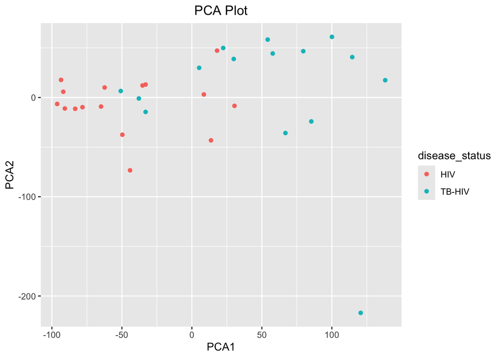

```r
set.seed(1)
pca_out <- prcomp(t(assay(sce_hivtb,"log_counts_cpm")))

pca_plot <- as.data.frame(pca_out$x)
pca_plot$disease_status <- as.factor(sce_hivtb$disease_status)

g <- pca_plot %>% ggplot(aes(x=PC1, y=PC2, color=disease_status)) +
  geom_point(size=1.5) + xlab("PCA1") + ylab("PCA2") +
  theme(plot.title = element_text(hjust = 0.5)) +
  ggtitle("PCA Plot")

plot(g)
```

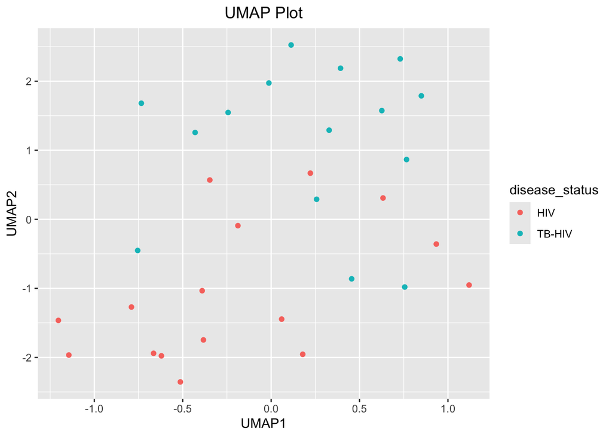

```r
set.seed(32)
umap_out <- umap(t(assay(sce_hivtb,"log_counts_cpm")))

umap_plot <- as.data.frame(umap_out$layout)
umap_plot$disease_status <- as.factor(sce_hivtb$disease_status)

g <- umap_plot %>% ggplot(aes(x=V1, y=V2, color=disease_status)) +
  geom_point(size=1.5) + xlab("UMAP1") + ylab("UMAP2") +
  theme(plot.title = element_text(hjust = 0.5)) +
  ggtitle("UMAP Plot")
plot(g)
```

### Deseq2

```r
#colData is a data frame of demographic/phenotypic data
dds <- DESeqDataSetFromMatrix(countData = counts,
                              colData=meta_data,
                              design=~disease_status)

#Gene Filtering
dds<-dds[rowSums(counts(dds))>1,]
```

```r
#Performs estimation of size factors,
#dispersion, and negative binomial GLM fitting
dds<-DESeq(dds)
```

```
##   Note: levels of factors in the design contain characters other than
##   letters, numbers, '_' and '.'. It is recommended (but not required) to use
##   only letters, numbers, and delimiters '_' or '.', as these are safe characters
##   for column names in R. [This is a message, not a warning or an error]
```

[output not shown]

[output not shown]

```
## -- replacing outliers and refitting for 390 genes
## -- DESeq argument 'minReplicatesForReplace' = 7
## -- original counts are preserved in counts(dds)
```

[output not shown]

```r
res <- results(dds)[order(results(dds)[,6]),]
datatable(as.data.frame(res[1:50,]), options = list(pageLength=5))
```

|  | baseMean | log2FoldChange | lfcSE | stat | pvalue | padj |
| --- | --- | --- | --- | --- | --- | --- |
| TIFA | 1594.20409877817 | 2.236634691989171 | 0.2588147348758348 | 8.641836768150725 | 5.531642286020393e-18 | 5.100848567866032e-14 |
| DDX10P1 | 64.84416822040995 | 2.600857236545671 | 0.2992287724409275 | 8.691868817725814 | 3.565256119527044e-18 | 5.100848567866032e-14 |
| INSL3 | 191.7831948460233 | 2.359309539242051 | 0.273186061281225 | 8.636273491323244 | 5.807638128049678e-18 | 5.100848567866032e-14 |
| IL18R1 | 1351.031909493794 | 2.935632098174024 | 0.3416974494130425 | 8.591319903665548 | 8.597588876036828e-18 | 5.663446732367359e-14 |
| IL1R2 | 6261.638618815699 | 4.370190632562231 | 0.5120285110599937 | 8.535053299112443 | 1.400908323133214e-17 | 7.382506681247412e-14 |
| RAB20 | 551.8746867471276 | 2.439707100320858 | 0.2892524977574975 | 8.434523882197384 | 3.325538499528065e-17 | 1.46041023206775e-13 |
| CYP1B1 | 2061.163180353584 | 3.424105441143563 | 0.4096330795432848 | 8.358957350224808 | 6.327497909190812e-17 | 2.381760605846696e-13 |
| SOCS3 | 1455.087082682306 | 2.973437836192544 | 0.3586988493022764 | 8.28951038448083 | 1.137155881029541e-16 | 3.745365038655921e-13 |
| MAP3K20 | 1285.925914176944 | 2.675030664423697 | 0.328174439329313 | 8.15124623931904 | 3.601928442321571e-16 | 1.054524583630345e-12 |
| CFH | 96.41206777778915 | 3.216835865535978 | 0.395331511857677 | 8.137059073333038 | 4.049951385215419e-16 | 1.067121690490411e-12 |

[output cut: 40 more lines]

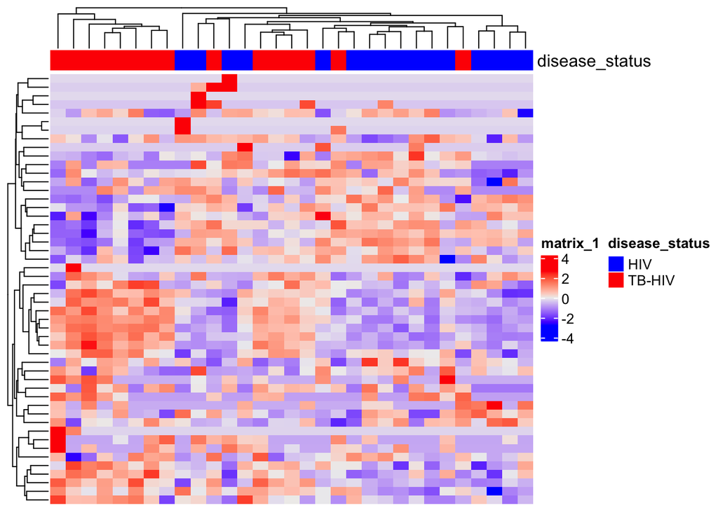

```r
# Make a Heatmap of DEGs
mat = as.matrix(assay(sce_hivtb,"log_counts_cpm")
                )[order(results(dds)[,6])[1:50],]

# Using first 1000 genes to simplify
mat = t(scale(t(mat)))
df = data.frame(disease_status=colData(sce_hivtb)$disease_status)

ha = HeatmapAnnotation(df = df,
                       col = list(disease_status=c(
                         "TB-HIV"="Red",
                         "HIV"="Blue")))

Heatmap(mat,show_row_names=F, show_column_names = F, top_annotation = ha)
```

### Limma

```r
#From edgeR, Computes library size
dge <- DGEList(counts=counts, group=group[1:31])

#Gene Filtering
counts<-counts[which(rowSums(cpm(counts))>1),]
dge <- DGEList(counts=counts, group=group)
dge <- calcNormFactors(dge) #TMM normalization
```

```r
design<-model.matrix(~group)
#voom transform to calculate weights to
#eliminate mean-variance relationship
v<-voom(dge, design)
#use usual limma pipelines
fit<-lmFit(v,design)
fit<-eBayes(fit)
```

```r
# topTable(fit, coef=ncol(design), number=50)
datatable(topTable(fit, coef=ncol(design), number=50), options = list(pageLength=5))
```

|  | logFC | AveExpr | t | P.Value | adj.P.Val | B |
| --- | --- | --- | --- | --- | --- | --- |
| VNN1 | 3.444386889713564 | 6.596975385807072 | 8.060400834596365 | 1.11221319710815e-09 | 2.199966475850434e-05 | 12.10432958982414 |
| TIFA | 2.028007668865736 | 5.865366599440871 | 7.97621665368206 | 1.42937887037124e-09 | 2.199966475850434e-05 | 11.86167181388747 |
| INSL3 | 2.213247487750663 | 2.753710201271933 | 7.860251135890143 | 2.022028010891943e-09 | 2.199966475850434e-05 | 11.44461370293268 |
| SOCS3 | 2.835097759545602 | 5.254662955764718 | 7.718295394264385 | 3.097612587223754e-09 | 2.527651871174583e-05 | 11.11202365669628 |
| IL18R1 | 2.70911100704334 | 5.208025379829514 | 7.433184592943523 | 7.340534259785146e-09 | 3.64860977583153e-05 | 10.27719069864948 |
| RAB20 | 2.183268517397514 | 4.215884042268772 | 7.354329961151095 | 9.33155561834016e-09 | 3.64860977583153e-05 | 10.04459243684475 |
| SBNO2 | 1.472645776206918 | 5.903385231459696 | 7.283800466940827 | 1.157132851084916e-08 | 3.64860977583153e-05 | 9.82880560799911 |
| LYRM1 | 0.9964360964594103 | 5.145883796625998 | 7.252342696140217 | 1.273843696813152e-08 | 3.64860977583153e-05 | 9.742529877701404 |
| ALDH1A2 | 2.284716840129488 | 2.132116650028368 | 7.250767268353813 | 1.279991653635708e-08 | 3.64860977583153e-05 | 9.659562977730204 |
| BCL6 | 2.427607949733467 | 10.01559246327964 | 7.224687773038802 | 1.386228317647414e-08 | 3.64860977583153e-05 | 9.589367627693921 |

[output cut: 40 more lines]

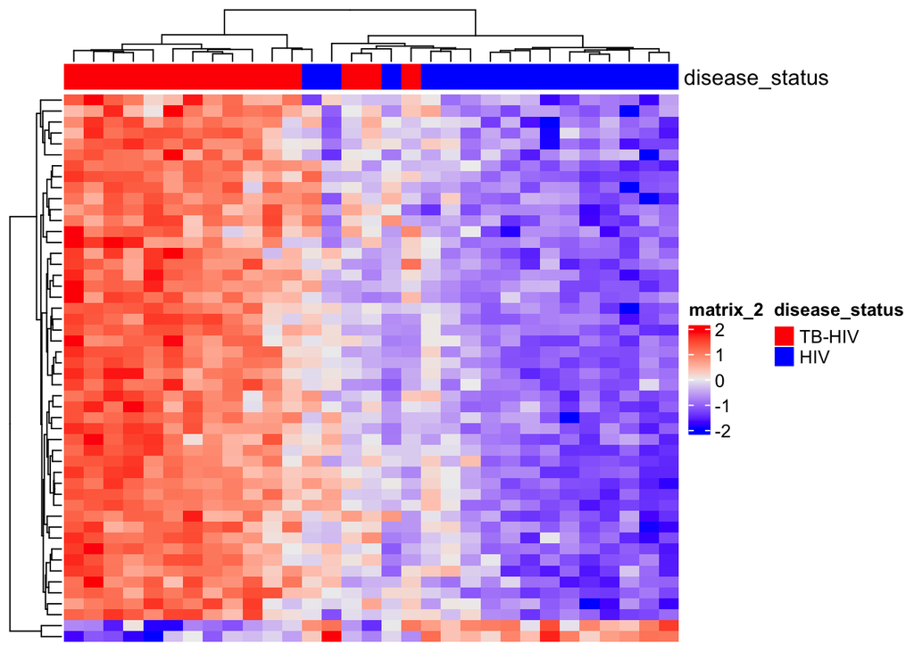

```r
# Get top differentially expressed genes
top_genes <- topTable(fit, coef=ncol(design), number=50)
top_genes_limma <- top_genes
degs <- rownames(top_genes)

# Extract log CPM for DEGs
log_cpm <- cpm(dge, log=TRUE)
mat <- log_cpm[degs, ]

# Normalize the matrix for heatmap visualization
mat <- t(scale(t(mat)))

# Create a data frame for annotation
df <- data.frame(disease_status=colData(sce_hivtb)$disease_status)

# Ensure levels match exactly
df$disease_status <- factor(df$disease_status, levels=c("TB-HIV", "HIV"))

# Create heatmap annotation
ha <- HeatmapAnnotation(df=df,
                        col=list(disease_status=c("TB-HIV"="Red", "HIV"="Blue")))

# Generate heatmap
Heatmap(mat, show_row_names=FALSE, show_column_names=FALSE, top_annotation=ha)
```

Out of the first top 50 genes 28 genes are found in both results of Deseq2 and Limma. Here is the plot of log2 Fold changes of Deseq2 and Limma. The log2FC values are approximately equal.

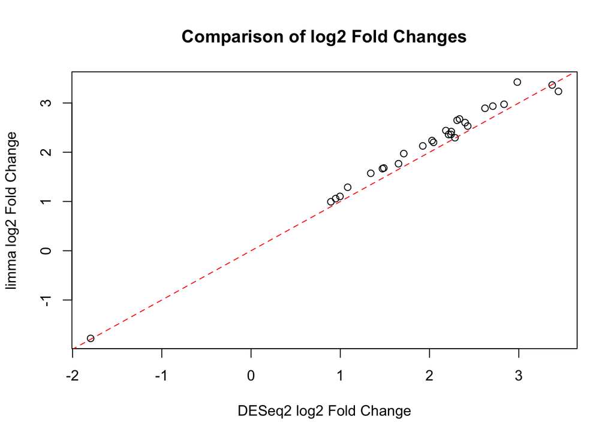

```r
top_genes_limma$gene <- rownames(top_genes_limma)
top_genes_deseq2 <- as.data.frame(res[1:50,])
top_genes_deseq2$gene <- rownames(top_genes_deseq2)
merged_results <- merge(top_genes_limma, top_genes_deseq2, by = "gene")

plot(merged_results$logFC, merged_results$log2FoldChange,
     xlab = "DESeq2 log2 Fold Change", ylab = "limma log2 Fold Change",
     main = "Comparison of log2 Fold Changes")

abline(0, 1, col = "red", lty = 2)
```

### Pathway analysis

```r
# Select EnrichR libraries
dbs <- c("KEGG_2021_Human", "Reactome_2022")

# Perform the enrichment analysis
results <- enrichr(rownames(top_genes), dbs)
```

```
## Uploading data to Enrichr... Done.
##   Querying KEGG_2021_Human... Done.
##   Querying Reactome_2022... Done.
## Parsing results... Done.
```

Here is the resulted top scoring pathways of **KEGG_2021_Human** and **Reactome_2022**

```r
datatable(results$KEGG_2021_Human, options = list(pageLength=5))
```

|  | Term | Overlap | P.value | Adjusted.P.value | Old.P.value | Old.Adjusted.P.value | Odds.Ratio | Combined.Score | Genes |
| --- | --- | --- | --- | --- | --- | --- | --- | --- | --- |
| 1 | Adipocytokine signaling pathway | 3/69 | 0.0006858216610371124 | 0.03410289889970194 | 0 | 0 | 19.23017408123791 | 140.0897592718836 | SOCS3;ACSL1;ACSL4 |
| 2 | PPAR signaling pathway | 3/74 | 0.000841115699760175 | 0.03410289889970194 | 0 | 0 | 17.87144141444411 | 126.5437687687522 | GK;ACSL1;ACSL4 |
| 3 | Fatty acid biosynthesis | 2/18 | 0.000913470506242016 | 0.03410289889970194 | 0 | 0 | 51.91145833333334 | 363.2898548418271 | ACSL1;ACSL4 |
| 4 | TNF signaling pathway | 3/112 | 0.002766936229061339 | 0.07747421441371749 | 0 | 0 | 11.61877805973063 | 68.43477270112554 | SOCS3;MAPK14;IL18R1 |
| 5 | Osteoclast differentiation | 3/127 | 0.003942447615787695 | 0.08289105860467849 | 0 | 0 | 10.20555936856554 | 56.49750237396662 | SOCS3;FCGR1A;MAPK14 |
| 6 | Ferroptosis | 2/41 | 0.004719495169738577 | 0.08289105860467849 | 0 | 0 | 21.27243589743589 | 113.9363034798657 | ACSL1;ACSL4 |
| 7 | Fatty acid degradation | 2/43 | 0.005180691162792406 | 0.08289105860467849 | 0 | 0 | 20.23272357723577 | 106.4811176026369 | ACSL1;ACSL4 |
| 8 | Inflammatory bowel disease | 2/65 | 0.01152376186612317 | 0.135155496624003 | 0 | 0 | 13.15277777777778 | 58.70537343689256 | TLR5;IL18R1 |
| 9 | Neutrophil extracellular trap formation | 3/189 | 0.01175569133967719 | 0.135155496624003 | 0 | 0 | 6.782429649965683 | 30.13716854116709 | H4C9;FCGR1A;MAPK14 |
| 10 | Epithelial cell signaling in Helicobacter pylori infection | 2/70 | 0.01327420056128601 | 0.135155496624003 | 0 | 0 | 12.18259803921568 | 52.65237170003471 | MAPK14;ATP6V1C1 |

[output cut: 102 more lines]

```r
datatable(results$Reactome_2022, options = list(pageLength=5))
```

|  | Term | Overlap | P.value | Adjusted.P.value | Old.P.value | Old.Adjusted.P.value | Odds.Ratio | Combined.Score | Genes |
| --- | --- | --- | --- | --- | --- | --- | --- | --- | --- |
| 1 | Immune System R-HSA-168256 | 14/1943 | 0.0002062285811323917 | 0.03270829250155926 | 0 | 0 | 3.63305685156385 | 30.83202920392749 | CD274;FYB1;MAPK14;SOCS3;AIM2;VNN1;BCL6;TIFA;IL6ST;TLR5;FCGR1A;PAG1;ATP6V1C1;IL18R1 |
| 2 | Interleukin-6 Signaling R-HSA-1059683 | 2/11 | 0.000332063883264561 | 0.03270829250155926 | 0 | 0 | 92.31944444444444 | 739.4956618223716 | SOCS3;IL6ST |
| 3 | Signaling By Interleukins R-HSA-449147 | 6/453 | 0.0008928708037776335 | 0.05020130755486561 | 0 | 0 | 5.949664429530201 | 41.77300248853254 | SOCS3;BCL6;TIFA;IL6ST;MAPK14;IL18R1 |
| 4 | Synthesis Of Very Long-Chain Fatty acyl-CoAs R-HSA-75876 | 2/24 | 0.001632124977335775 | 0.05020130755486561 | 0 | 0 | 37.74242424242424 | 242.2260645953166 | ACSL1;ACSL4 |
| 5 | Interleukin-6 Family Signaling R-HSA-6783589 | 2/24 | 0.001632124977335775 | 0.05020130755486561 | 0 | 0 | 37.74242424242424 | 242.2260645953166 | SOCS3;IL6ST |
| 6 | Cytokine Signaling In Immune System R-HSA-1280215 | 7/702 | 0.001711172171171617 | 0.05020130755486561 | 0 | 0 | 4.510122134850259 | 28.73207881993791 | SOCS3;BCL6;TIFA;IL6ST;FCGR1A;MAPK14;IL18R1 |
| 7 | MyD88 Cascade Initiated On Plasma Membrane R-HSA-975871 | 3/96 | 0.001783802806518068 | 0.05020130755486561 | 0 | 0 | 13.62868908716541 | 86.25607933742052 | TIFA;TLR5;MAPK14 |
| 8 | Fatty acyl-CoA Biosynthesis R-HSA-75105 | 2/37 | 0.003857631592439223 | 0.09499417796381586 | 0 | 0 | 23.70833333333333 | 131.7638482857208 | ACSL1;ACSL4 |
| 9 | Toll-like Receptor Cascades R-HSA-168898 | 3/162 | 0.007738162912414867 | 0.1298001948372908 | 0 | 0 | 7.945002007226013 | 38.62535000995355 | TIFA;TLR5;MAPK14 |
| 10 | Nucleotide-binding Domain, Leucine Rich Repeat Containing NLR Signaling Pathways R-HSA-168643 | 2/53 | 0.00778121248393933 | 0.1298001948372908 | 0 | 0 | 16.25735294117647 | 78.94640668269977 | AIM2;MAPK14 |

[output cut: 187 more lines]

### TBSignatureProfiler analysis

```r
sce_hivtb_3 <- sce_hivtb

TBsigs <- TBsignatures[-12]

ssgsea_res <- runTBsigProfiler(sce_hivtb_3,
                               useAssay = "log_counts_cpm",
                               signatures = TBsigs,
                               algorithm = "ssGSEA",
                               combineSigAndAlgorithm = TRUE,
                               parallel.sz = 1)
```

```
## Parameter update_genes is TRUE. Gene names will be updated.
```

```
## Running ssGSEA
```

[output not shown]

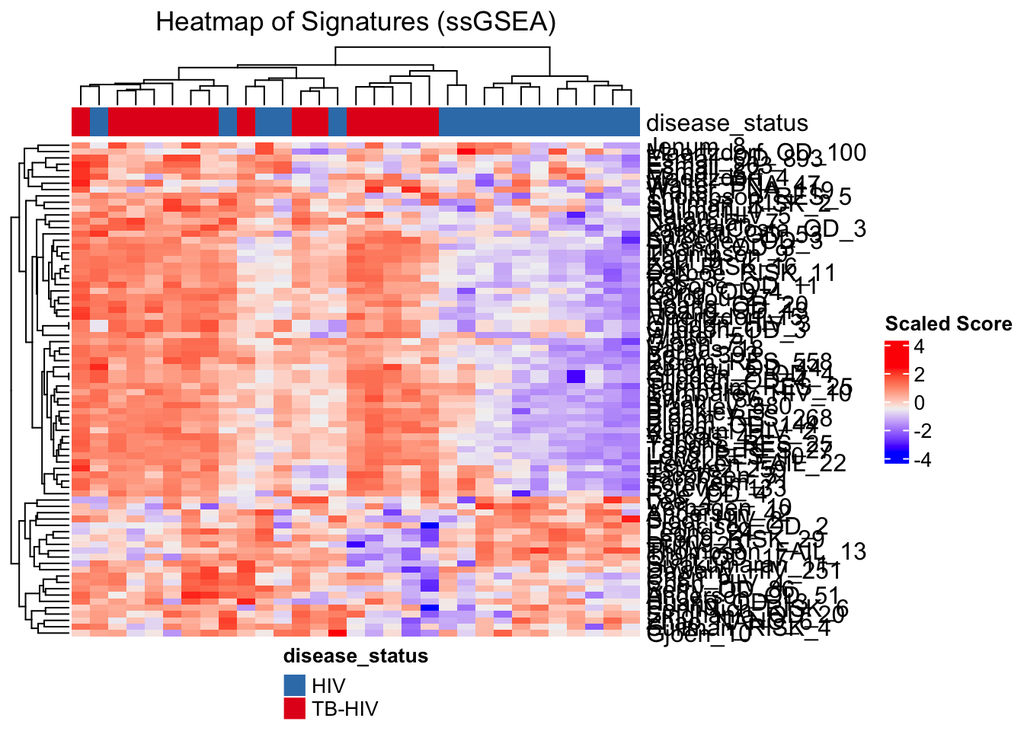

```r
# Colors for gradient
signatureHeatmap(ssgsea_res,
                 name = "Heatmap of Signatures (ssGSEA)",
                 signatureColNames = names(TBsigs),
                 annotationColNames = c("disease_status"),
                 scale = TRUE,
                 split_heatmap = "none",
                 showColumnNames = FALSE)
```

Here, we observe the that ssGSEA score for HIV samples is less than for TB-HIV samples in both cases of Sweeney_OD_3 and Zak_RISK_16 gene signatures

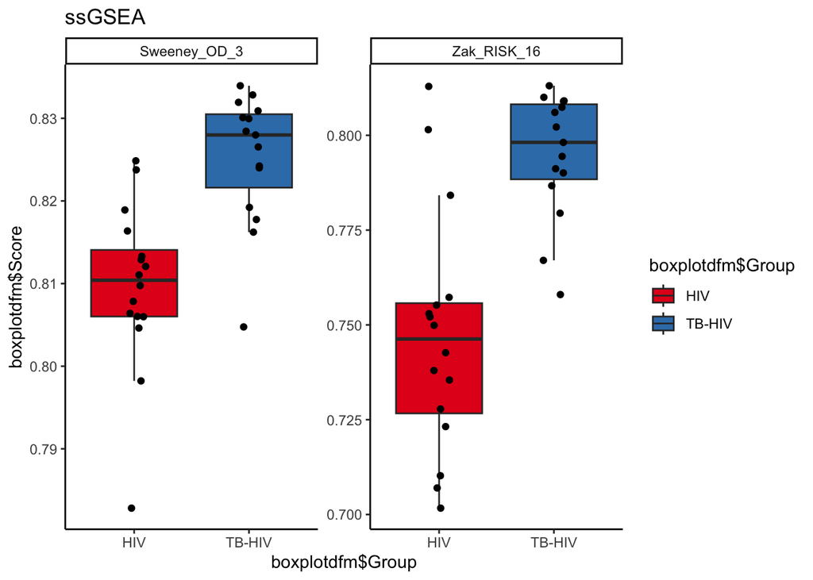

```r
signatureBoxplot(ssgsea_res, name="ssGSEA",
                 signatureColNames = names(TBsigs)[c(62,77)],
                 annotationColName = c("disease_status"))
```

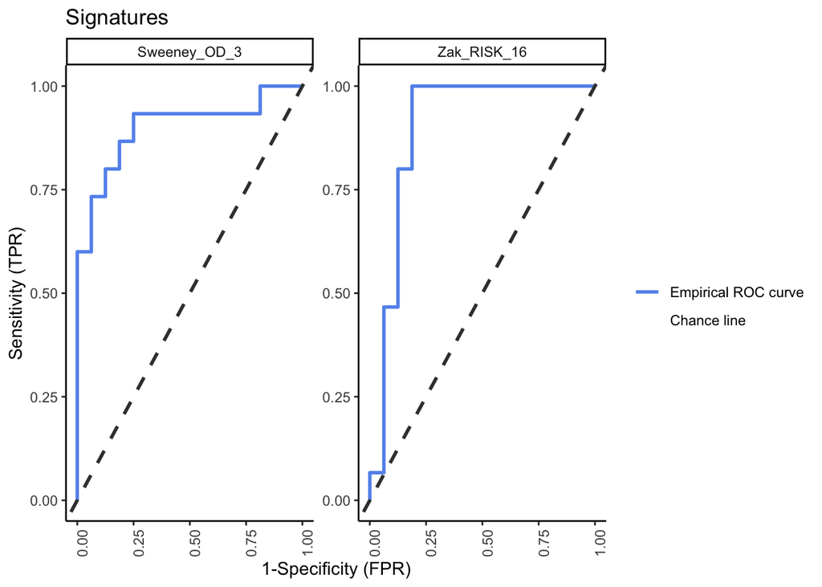

```r
signatureROCplot(ssgsea_res, signatureColNames = names(TBsigs)[c(62, 77)], annotationColName = c("disease_status"))
```